# A lncRNA signature for metastasis prediction of LA-NPC

This a R markdown file contains codes that reproduce the main results of our study. The required data format and expected outputs can be found in the corresponding html file.

## Differential expression analysis

Differential expression analysis of microarray data was performed with GeneSpring GX v12.1 software (Agilent Technologies) and 149 differentially expressed (DE) lncRNAs were identified. Model development and validation, and the function implication analyses were performed using the following codes.

Load packages

```r
library(dplyr)
library(ggplot2)
library(pROC)
library(tableone)
library(circlize)
library(ggplotify)
library(tibble)
library(tidyr)
library(survival)
library(survminer)
library(glmnet)
library(gridExtra)
library(cowplot)
library(Hmisc)
library(forestplot)
library(msigdbr)
library(clusterProfiler)
library(enrichplot)
library(sva)
library(pheatmap)
library(ggpubr)
library(limma)
library(stringr)
library(org.Hs.eg.db)
library(ComplexHeatmap)
library(GSVA)
library(MCPcounter)
library(ggunchained)
library(scales)
```

## Training

Input data - TrainingData contains the expression of the 149 DE lncRNAs by qRT-PCR and clinical information of each patients in the training cohort.

```r
TrainingData<-read.csv("Cohort-Training.csv",header = T,row.names = 1,check.names = F)
TrainingData[1:3,]
```

```
##      ENST00000561761 ENST00000430259 ENST00000414890 ENST00000573040
## T001           10.38            9.04            9.64           10.56
## T002           11.89           11.42           10.67           12.39
## T003           10.96            9.50            8.27           10.87
##      ENST00000545709 ENST00000605386 ENST00000508640 ENST00000499560
## T001           10.20           12.91            9.09            9.04
## T002           13.47           15.10           11.46           10.61
## T003           11.36           12.95           10.26            9.94
##      ENST00000605298 ENST00000414750 ENST00000569274 ENST00000450546
## T001            9.49           11.28            6.06           10.21
## T002           11.20           12.25            8.13           13.21
## T003           10.06           10.45            6.47            9.95
##      ENST00000510225 ENST00000421851 ENST00000569353 ENST00000449852
## T001            9.82           11.15            9.26           11.35
## T002           14.10           13.33           11.19           12.91
## T003           10.04           11.57            9.24           10.29
##      ENST00000510592 ENST00000587128 ENST00000462717 ENST00000512105
## T001           11.42           10.52           13.46            8.20
## T002           14.65           11.06           14.76           11.96
## T003           13.77           10.33           12.23            8.77
##      ENST00000484172 ENST00000427722 ENST00000444319 ENST00000606285
## T001            9.98           10.27            9.37            8.63
## T002           13.40           11.20            9.31           10.26
## T003           12.46            9.66            8.18            9.90
##      ENST00000541775 ENST00000431803 ENST00000563434 ENST00000565519
## T001            7.93            8.22           10.06           13.76
## T002            8.32           10.10           12.32           13.06
## T003            7.62            7.98           10.36           12.99
##      ENST00000498714 ENST00000514452 ENST00000596585 ENST00000417120
## T001            7.71           11.14           10.20            8.79
## T002           10.07           16.58           11.27           11.14
## T003            8.25           11.88            9.92            9.42
##      ENST00000565382 ENST00000444482 ENST00000431759 ENST00000431813
## T001           12.59            8.61           11.55            9.91
## T002           13.02           10.83           12.91           11.23
## T003           11.01            8.32           11.33            9.88
##      ENST00000457043 ENST00000565058 ENST00000510682 ENST00000470435
## T001            8.79            9.83           11.32           12.77
## T002            9.87           11.19           12.96           14.26
## T003            8.46            7.66            9.81           11.31
```

[output cut: 73 more lines]

```
## T001           10.33           10.47           10.04           10.89
## T002           13.61           12.05            9.64           12.67
## T003           10.89            9.84            7.96           11.09
##      ENST00000414085 ENST00000514011 ENST00000504829 ENST00000423256
## T001            8.14           11.47           10.50           10.41
## T002           10.97           13.11           13.16            9.91
## T003            9.14           12.50           10.37            8.67
##      ENST00000419129 Sex Age AgeGroup EBVDNA EBVDNAGroup Progression   DFS
## T001           10.41   1  60        1  92.90           1           1 10.90
## T002           14.90   1  60        1   6.56           1           1  4.00
## T003           20.19   1  16        0   0.00           0           1 11.93
##      Metastasis  DMFS Death    OS Tstage Nstage TMN Tgroup Ngroup
## T001          1 10.90     1 28.03      3      1   3      1      0
## T002          1  4.00     1 24.47      4      1   4      1      0
## T003          1 11.93     0 80.23      4      3   4      1      1
```

- DElnc contains the probe_id, gene symbol of the 149 DE lncRNAs and whether they were selected to model construction.

```r
DElnc <- read.csv("DE_lncRNA.csv",row.names = 1,header = T)
head(DElnc)
```

```
##                      probe_id gencode_GeneSymbol lncipedia_GeneSymbol
## ENST00000561761 ASHGA5P045044         AC103706.1          lnc-WISP1-2
## ENST00000430259 ASHGA5P037374         AP001469.3            lnc-LSS-1
## ENST00000414890 ASHGA5P042820       RABGAP1L-IT1         RABGAP1L-IT1
## ENST00000573040 ASHGA5P031736         AC007599.2           lnc-GPT2-4
## ENST00000545709 ASHGA5P028113         AC026124.1          lnc-LEMD3-1
## ENST00000605386 ASHGA5P028200         ATP2B1-AS1           ATP2B1-AS1
##                 lnc_signature
## ENST00000561761    unselected
## ENST00000430259    unselected
## ENST00000414890    unselected
## ENST00000573040    unselected
## ENST00000545709    unselected
## ENST00000605386    unselected
```

Univariate Cox analysis to identify lncRNAs related to DMFS

```r
covariates1 <- colnames(TrainingData)[1:length(grep("ENST",colnames(TrainingData)))]
covariates2 <- c("AgeGroup","Sex","Tgroup","Ngroup","EBVDNAGroup")
covariates <- union(covariates1,covariates2)
univ_formulas1 <- sapply(covariates,function(x) as.formula(paste('Surv(DMFS, Metastasis)~', x)))
univ_models1 <- lapply(univ_formulas1, function(x){coxph(x, data = TrainingData)})
univ_results1 <- lapply(univ_models1,
                        function(x){
                          x <- summary(x)
                          wald.p.value<-sprintf("%.8f",x$waldtest["pvalue"])
                          wald.test<-signif(x$wald["test"], digits=3)
                          beta<-sprintf("%.2f",x$coef[1]);#coeficient beta
                          HR <-sprintf("%.2f",x$coef[2]);#exp(beta)
                          HR.confint.lower <- sprintf("%.2f",x$conf.int[,"lower .95"])
                          HR.confint.upper <- sprintf("%.2f",x$conf.int[,"upper .95"])
                          HR <- paste0(HR, " (",
                                       HR.confint.lower, "-", HR.confint.upper, ")")
                          res<-c(beta, HR, wald.test, wald.p.value)
                          names(res)<-c("beta", "HR (95% CI for HR)", "wald.test", "wald.p.value")
                          return(res)
                        })
res <- t(as.data.frame(univ_results1, check.names = FALSE))
res <- as.data.frame(res)
exlist<-which(res$wald.p.value>=0.05)
TrainingData_origin<-TrainingData
TrainingData<-TrainingData_origin[,-exlist]
#only lncRNAs related to DMFS were included in signature development
```

Model development using LASSO

```r
x1<-as.matrix(TrainingData[,1:length(grep("ENST",colnames(TrainingData)))])
y1<-cbind(time=TrainingData$DMFS,status=TrainingData$Metastasis)

set.seed(1)
cv.fit<-cv.glmnet(x1,y1,family="cox",nfolds=10,alpha=1,nlambda=1000)
modelcoef<-coef(cv.fit, s = cv.fit$lambda.min)
selected_lncs<-colnames(TrainingData)[which(modelcoef!=0)]
selected_lncs
```

```
## [1] "ENST00000605298" "ENST00000514452" "ENST00000561402" "ENST00000565861"
## [5] "ENST00000517854" "ENST00000509924" "ENST00000447898" "ENST00000358073"
## [9] "ENST00000534431"
```

```r
DElnc[selected_lncs,"lncipedia_GeneSymbol"]
```

```
## [1] "lnc-TRAPPC6B-2" "lnc-DRD5-10"    "NR2F2-AS1"      "lnc-CETP-1"
## [5] "lnc-CDK1-1"     "LINC02065"      "lnc-POTEH-7"    "lnc-STX6-2"
## [9] "lnc-C11orf91-2"
```

```r
lncs_coef<-as.numeric(sprintf(" %.3f",modelcoef[which(modelcoef!=0)]))
lncs_coef
```

```
## [1]  0.117  0.042 -0.054  0.077  0.121  0.100  0.196 -0.409 -0.109
```

```r
lncs_number<-length(selected_lncs)
riskscore <- 0
for (l in 1:lncs_number){
  coef <- lncs_coef[l]
  lnc <- TrainingData[,selected_lncs[l]]
  riskscore <- riskscore+coef*lnc
}
names(riskscore)<-"riskscore"
data_train<-cbind(TrainingData_origin,riskscore)

riskscore_ROC <- roc(data_train$Metastasis,data_train$riskscore,levels=c(control = 0, case = 1),direction="<")
cutoff <- riskscore_ROC$thresholds[which.max(riskscore_ROC$sensitivities+riskscore_ROC$specificities)]
data_train$lncRNA_signature<-cut(data_train$riskscore,breaks = c(-100,cutoff,100),labels = c(0,1))
```

Multivariate Cox analysis

```r
summary(coxph(Surv(DMFS, Metastasis)~Ngroup+EBVDNAGroup+lncRNA_signature, data = data_train))
summary(coxph(Surv(DFS, Progression)~Ngroup+EBVDNAGroup+AgeGroup+lncRNA_signature, data = data_train))
summary(coxph(Surv(OS, Death)~AgeGroup+Ngroup+EBVDNAGroup+lncRNA_signature, data = data_train))
```

KM curves (Fig.2A-C)

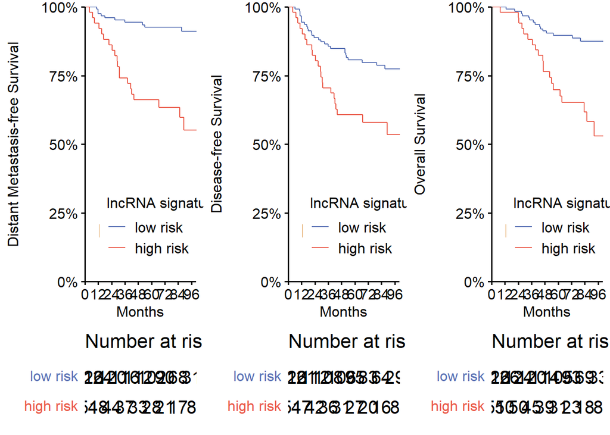

```r
modelplots <- list()
model_DMFS<- survfit(Surv(DMFS, Metastasis) ~ lncRNA_signature, data = data_train)
modelplots[[1]]<-ggsurvplot(model_DMFS, data=data_train,palette = c("#5a72b5","#ea5a49"),size=0.5,
                            conf.int = F,pval = T,censor=F,pval.size=5.25,pval.coord=c(12,0.2),
                            legend.title="lncRNA signature",legend.labs=c("low risk","high risk"),
                            legend=c(0.7,0.2),font.legend=12,
                            xlab="Months",break.time.by=12,ylab="Distant Metastasis-free Survival",surv.scale="percent",font.x=12,font.y=12,axes.offset=F,font.tickslab=12,xlim=c(0,100),
                            risk.table = T,tables.height=0.25,risk.table.fontsize=5.25,tables.theme = theme_cleantable())
model_DFS<- survfit(Surv(DFS, Progression) ~ lncRNA_signature, data = data_train)
modelplots[[2]]<-ggsurvplot(model_DFS, data=data_train,palette = c("#5a72b5","#ea5a49"),size=0.5,
                            conf.int = F,pval = T,censor=F,pval.size=5.25,pval.coord=c(12,0.2),
                            legend.title="lncRNA signature",legend.labs=c("low risk","high risk"),
                            legend=c(0.7,0.2),font.legend=12,
                            xlab="Months",break.time.by=12,ylab="Disease-free Survival",surv.scale="percent",font.x=12,font.y=12,axes.offset=F,font.tickslab=12,xlim=c(0,100),
                            risk.table = T,tables.height=0.25,risk.table.fontsize=5.25,tables.theme = theme_cleantable())
model_OS<- survfit(Surv(OS, Death) ~ lncRNA_signature, data = data_train)
modelplots[[3]]<-ggsurvplot(model_OS, data=data_train,palette = c("#5a72b5","#ea5a49"),size=0.5,
                            conf.int = F,pval = T,censor=F,pval.size=5.25,pval.coord=c(12,0.2),
                            legend.title="lncRNA signature",legend.labs=c("low risk","high risk"),
                            legend=c(0.7,0.2),font.legend=12,
                            xlab="Months",break.time.by=12,ylab="Overall Survival",surv.scale="percent",font.x=12,font.y=12,axes.offset=F,font.tickslab=12,xlim=c(0,100),
                            risk.table = T,tables.height=0.25,risk.table.fontsize=5.25,tables.theme = theme_cleantable())
arrange_ggsurvplots(modelplots, print = TRUE,  ncol = 3, nrow = 1)
```

ROC analysis (Fig.4A and 4D)

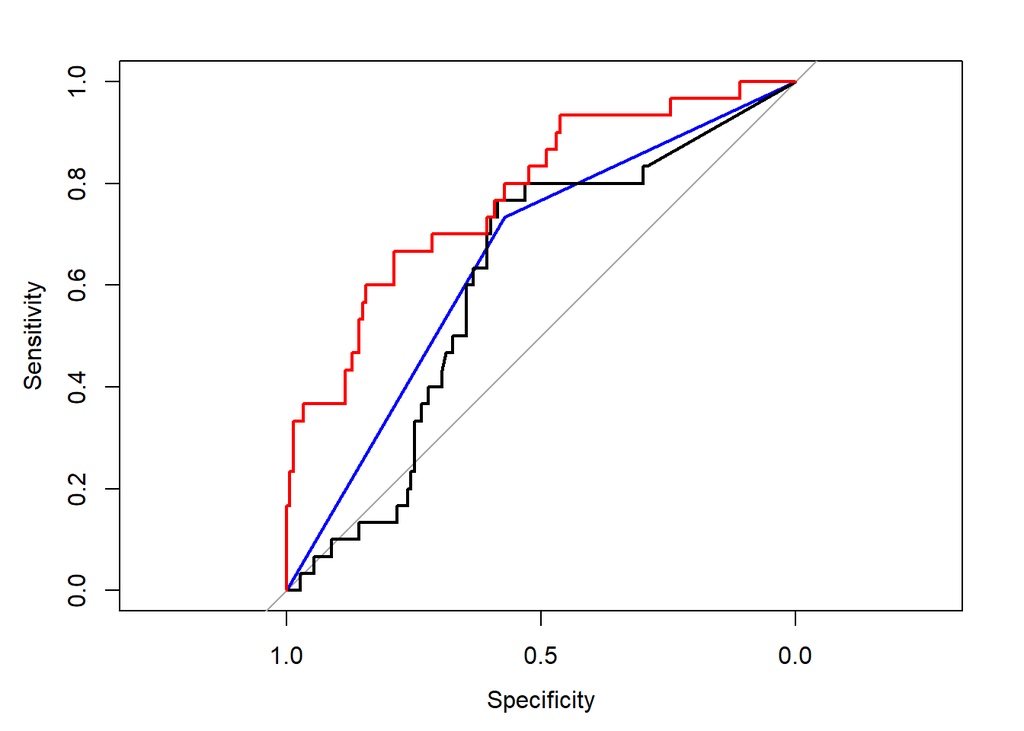

```r
riskscore_ROC <- roc(data_train$Metastasis,data_train$riskscore,levels=c(control = 0, case = 1),direction="<")
EBV_ROC <- roc(data_train$Metastasis,data_train$EBVDNA,levels=c(control = 0, case = 1),direction="<")
Ngroup_ROC <- roc(data_train$Metastasis,data_train$Ngroup,levels=c(control = 0, case = 1),direction="<")
#riskscore_ROC$auc; ci(riskscore_ROC)
#Ngroup_ROC$auc
#EBV_ROC$auc
#a1 <- roc.test(riskscore_ROC,EBV_ROC);a1$p.value
#a2 <- roc.test(riskscore_ROC,Ngroup_ROC);a2$p.value
plot(Ngroup_ROC,col="blue",lwd=2)
plot(EBV_ROC,col="black",lwd=2,add=T)
plot(riskscore_ROC,col="red",lwd=2,add=T)
```

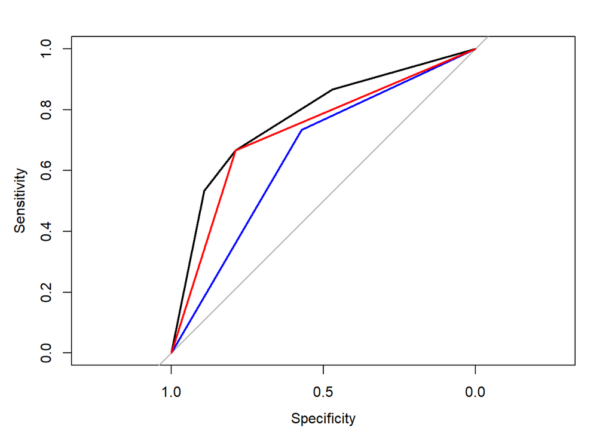

```r
data_train$lncRNA_signature <- as.numeric(data_train$lncRNA_signature)-1
#summary(coxph(Surv(DMFS, Metastasis)~Ngroup+lncRNA_signature, data = data_train))
data_train$lnc_N_score <- data_train$Ngroup+2*data_train$lncRNA_signature
lncsig_ROC <- roc(data_train$Metastasis,data_train$lncRNA_signature,levels=c(control = 0, case = 1),direction="<")
lnc_N_ROC <- roc(data_train$Metastasis,data_train$lnc_N_score,levels=c(control = 0, case = 1),direction="<")
#lncsig_ROC$auc
#lnc_N_ROC$auc
#b1 <- roc.test(Ngroup_ROC,lnc_N_ROC);b1$p.value
#b2 <- roc.test(lncsig_ROC,lnc_N_ROC);b2$p.value
plot(Ngroup_ROC,col="blue",lwd=2)
plot(lnc_N_ROC,col="black",lwd=2,add=T)
plot(lncsig_ROC,col="red",lwd=2,add=T)
```

## Internal Validation

- ValidationData contains the expression of the 9 selected lncRNAs by qRT-PCR and clinical information of each patients in the internal validation cohort.

```r
ValidationData<-read.csv("Cohort-Internal.csv",header = T,row.names = 1,check.names = F)
ValidationData[1:3,]
```

```
##      ENST00000605298 ENST00000514452 ENST00000561402 ENST00000565861
## I001            6.40            7.30           19.54            7.65
## I002            8.69            9.93           20.20            9.28
## I003            8.15            9.93            5.75            8.03
##      ENST00000517854 ENST00000509924 ENST00000447898 ENST00000358073
## I001            6.41            6.13            3.58            6.09
## I002            8.06            8.82            5.92            8.02
## I003            8.77           10.00            5.99            8.65
##      ENST00000534431 Sex Age AgeGroup EBVDNA EBVDNAGroup Progression    DFS
## I001            7.13   1  36        0   0.56           0           0 124.10
## I002            8.90   1  31        0   9.87           1           0 124.23
## I003           10.00   1  58        1   0.00           0           0 120.43
##      Metastasis   DMFS Death     OS Tstage Nstage TMN Tgroup Ngroup
## I001          0 124.10     0 124.10      3      0   3      1      0
## I002          0 124.23     0 124.23      4      1   4      1      0
## I003          0 120.43     0 120.43      3      1   3      1      0
```

riskscore calsulation

```r
riskscore_iv <- 0
for (l in 1:lncs_number){
  coef <- lncs_coef[l]
  lnc <- ValidationData[,selected_lncs[l]]
  riskscore_iv <- riskscore_iv+coef*lnc
}
ValidationData$riskscore<-riskscore_iv
ValidationData$lncRNA_signature<-cut(ValidationData$riskscore,breaks = c(-100,cutoff,100),labels = c(0,1))
data_invd <- ValidationData
```

Cox analysis

```r
# Univariate Cox
# Variables include AgeGroup,Sex,Tgroup,Ngroup,EBVDNAGroup
summary(coxph(Surv(DMFS, Metastasis)~AgeGroup, data = data_invd))

# Multivariate Cox
summary(coxph(Surv(DMFS, Metastasis)~Ngroup+EBVDNAGroup+lncRNA_signature, data = data_invd))
summary(coxph(Surv(DFS, Progression)~Sex+Ngroup+EBVDNAGroup+lncRNA_signature, data = data_invd))
summary(coxph(Surv(OS, Death)~Ngroup+EBVDNAGroup+Sex+lncRNA_signature, data = data_invd))
```

KM curves (Fig.2D-F)

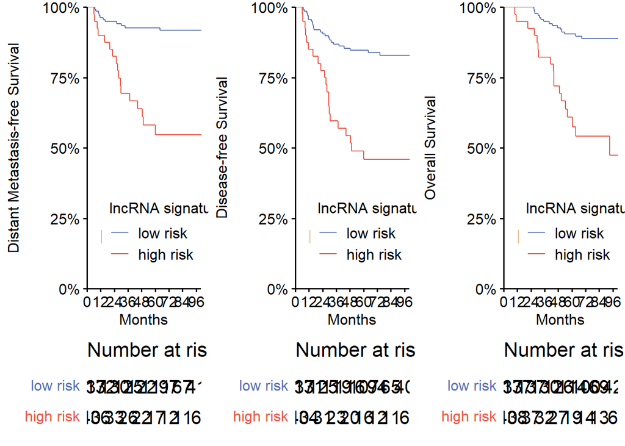

```r
modelplots <- list()
model_DMFS<- survfit(Surv(DMFS, Metastasis) ~ lncRNA_signature, data = data_invd)
modelplots[[1]]<-ggsurvplot(model_DMFS, data=data_invd,palette = c("#5a72b5","#ea5a49"),size=0.5,
                            conf.int = F,pval = T,censor=F,pval.size=5.25,pval.coord=c(12,0.2),
                            legend.title="lncRNA signature",legend.labs=c("low risk","high risk"),
                            legend=c(0.7,0.2),font.legend=12,
                            xlab="Months",break.time.by=12,ylab="Distant Metastasis-free Survival",surv.scale="percent",font.x=12,font.y=12,axes.offset=F,font.tickslab=12,xlim=c(0,100),
                            risk.table = T,tables.height=0.25,risk.table.fontsize=5.25,tables.theme = theme_cleantable())
model_DFS<- survfit(Surv(DFS, Progression) ~ lncRNA_signature, data = data_invd)
modelplots[[2]]<-ggsurvplot(model_DFS, data=data_invd,palette = c("#5a72b5","#ea5a49"),size=0.5,
                            conf.int = F,pval = T,censor=F,pval.size=5.25,pval.coord=c(12,0.2),
                            legend.title="lncRNA signature",legend.labs=c("low risk","high risk"),
                            legend=c(0.7,0.2),font.legend=12,
                            xlab="Months",break.time.by=12,ylab="Disease-free Survival",surv.scale="percent",font.x=12,font.y=12,axes.offset=F,font.tickslab=12,xlim=c(0,100),
                            risk.table = T,tables.height=0.25,risk.table.fontsize=5.25,tables.theme = theme_cleantable())
model_OS<- survfit(Surv(OS, Death) ~ lncRNA_signature, data = data_invd)
modelplots[[3]]<-ggsurvplot(model_OS, data=data_invd,palette = c("#5a72b5","#ea5a49"),size=0.5,
                            conf.int = F,pval = T,censor=F,pval.size=5.25,pval.coord=c(12,0.2),
                            legend.title="lncRNA signature",legend.labs=c("low risk","high risk"),
                            legend=c(0.7,0.2),font.legend=12,
                            xlab="Months",break.time.by=12,ylab="Overall Survival",surv.scale="percent",font.x=12,font.y=12,axes.offset=F,font.tickslab=12,xlim=c(0,100),
                            risk.table = T,tables.height=0.25,risk.table.fontsize=5.25,tables.theme = theme_cleantable())
arrange_ggsurvplots(modelplots, print = TRUE,  ncol = 3, nrow = 1)
```

ROC analysis (Fig.4B and 4E)

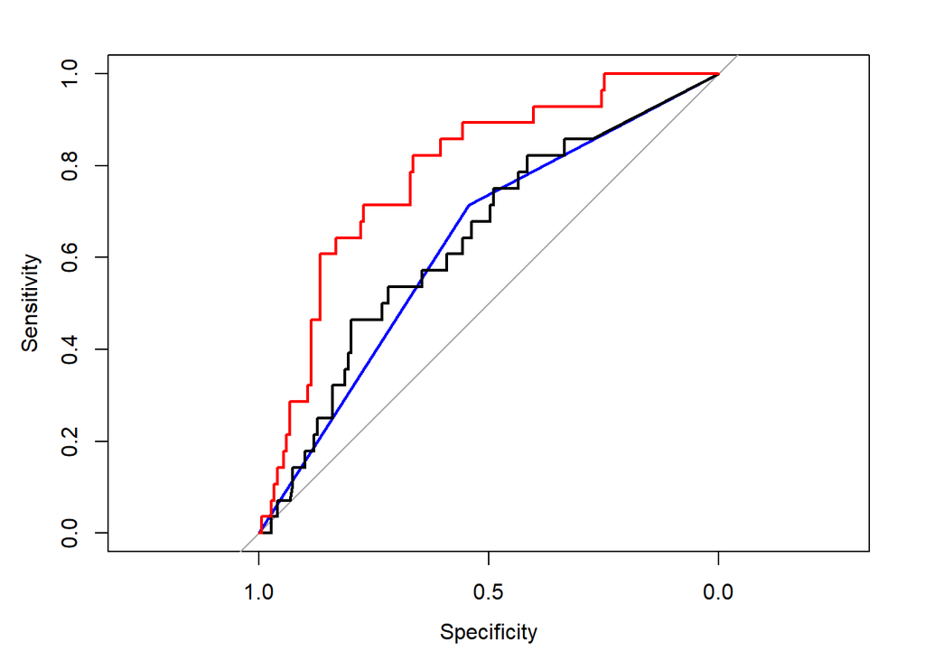

```r
riskscore_ROC_iv <- roc(data_invd$Metastasis,data_invd$riskscore,levels=c(control = 0, case = 1),direction="<")
EBV_ROC_iv <- roc(data_invd$Metastasis,data_invd$EBVDNA,levels=c(control = 0, case = 1),direction="<")
Ngroup_ROC_iv <- roc(data_invd$Metastasis,data_invd$Ngroup,levels=c(control = 0, case = 1),direction="<")
#riskscore_ROC_iv$auc; ci(riskscore_ROC_iv)
#EBV_ROC_iv$auc
#Ngroup_ROC_iv$auc
#roc.test(riskscore_ROC_iv,EBV_ROC_iv)
#roc.test(riskscore_ROC_iv,Ngroup_ROC_iv)
plot(Ngroup_ROC_iv,col="blue",lwd=2)
plot(EBV_ROC_iv,col="black",lwd=2,add=T)
plot(riskscore_ROC_iv,col="red",lwd=2,add=T)
```

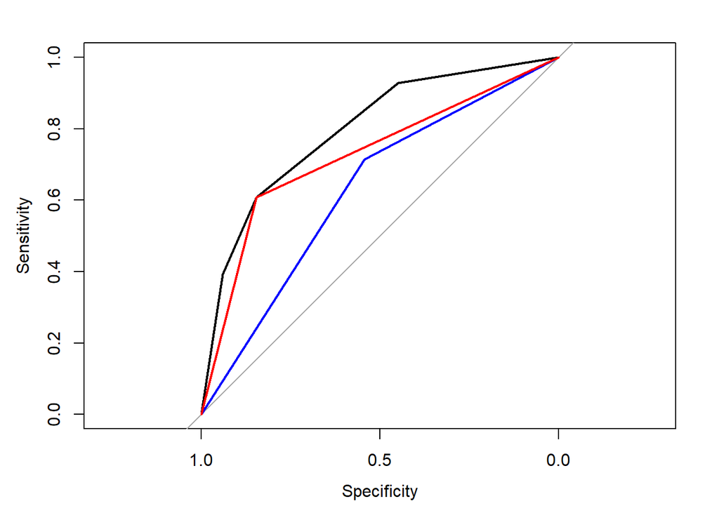

```r
data_invd$lncRNA_signature <- as.numeric(data_invd$lncRNA_signature)-1
data_invd$lnc_N_score <- data_invd$Ngroup+2*data_invd$lncRNA_signature
lncsig_ROC_iv <- roc(data_invd$Metastasis,data_invd$lncRNA_signature,levels=c(control = 0, case = 1),direction="<")
lnc_N_ROC_iv <- roc(data_invd$Metastasis,data_invd$lnc_N_score,levels=c(control = 0, case = 1),direction="<")
#lncsig_ROC_iv$auc
#lnc_N_ROC_iv$auc
#roc.test(Ngroup_ROC_iv,lnc_N_ROC_iv)
#roc.test(lncsig_ROC_iv,lnc_N_ROC_iv)
plot(Ngroup_ROC_iv,col="blue",lwd=2)
plot(lnc_N_ROC_iv,col="black",lwd=2,add=T)
plot(lncsig_ROC_iv,col="red",lwd=2,add=T)
```

## External validation

- Guilindata contains the expression of the 9 selected lncRNAs by qRT-PCR and clinical information of each patients in the external validation cohort.

```r
Guilindata<-read.csv("Cohort-Guilin.csv",header = T,row.names = 1,check.names = F)
Guilindata[1:3,]
```

```
##      ENST00000605298 ENST00000514452 ENST00000561402 ENST00000565861
## G001            9.61            9.80            8.47           10.90
## G002            8.86            9.29            6.59            8.54
## G003            8.70            9.58            5.66            9.17
##      ENST00000517854 ENST00000509924 ENST00000447898 ENST00000358073
## G001            9.25           10.37            6.83            9.15
## G002            8.42            8.79            5.71            7.68
## G003            9.44            8.12            5.21            7.03
##      ENST00000534431 Sex Age AgeGroup EBVDNA EBVDNAGroup Progression   DFS
## G001           10.52   0  24        0     NA          NA           1 13.70
## G002            9.37   0  56        1     NA          NA           0 58.07
## G003            8.69   0  65        1     NA          NA           1  7.60
##      Metastasis  DMFS Death    OS Tstage Nstage TMN Tgroup Ngroup
## G001          1 13.70     1 21.07      2      3   4      0      1
## G002          0 58.07     0 58.07      2      2   3      0      1
## G003          1  7.60     1 31.27      4      2   4      1      1
```

riskscore calsulation

```r
riskscore_ev <- 0
for (l in 1:lncs_number){
  coef <- lncs_coef[l]
  lnc <- Guilindata[,selected_lncs[l]]
  riskscore_ev <- riskscore_ev+coef*lnc
}
Guilindata$riskscore<-riskscore_ev
Guilindata$lncRNA_signature<-cut(Guilindata$riskscore,breaks = c(-100,cutoff,100),labels = c(0,1))
```

KM curves (Fig.2G-I)

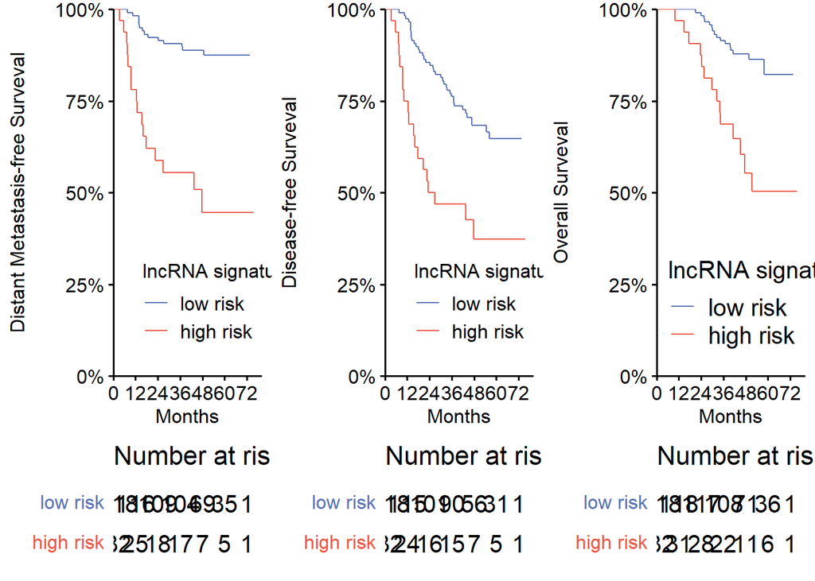

```r
modelplots <- list()
model_DMFS<- survfit(Surv(DMFS, Metastasis) ~ lncRNA_signature, data = Guilindata)
modelplots[[1]]<-ggsurvplot(model_DMFS, data=Guilindata,palette = c("#5a72b5","#ea5a49"),size=0.5,
                            conf.int = F,pval = T,censor=F,pval.size=5.25,pval.coord=c(12,0.2),
                            legend.title="lncRNA signature",legend.labs=c("low risk","high risk"),
                            legend=c(0.7,0.2),font.legend=12,
                            xlab="Months",break.time.by=12,ylab="Distant Metastasis-free Surveval",surv.scale="percent",font.x=12,font.y=12,axes.offset=F,font.tickslab=12,
                            risk.table = T,tables.height=0.25,risk.table.fontsize=5.25,tables.theme = theme_cleantable())
model_DFS<- survfit(Surv(DFS, Progression) ~ lncRNA_signature, data = Guilindata)
modelplots[[2]]<-ggsurvplot(model_DFS, data=Guilindata,palette = c("#5a72b5","#ea5a49"),size=0.5,
                            conf.int = F,pval = T,censor=F,pval.size=5.25,pval.coord=c(12,0.2),
                            legend.title="lncRNA signature",legend.labs=c("low risk","high risk"),
                            legend=c(0.7,0.2),font.legend=12,
                            xlab="Months",break.time.by=12,ylab="Disease-free Surveval",surv.scale="percent",font.x=12,font.y=12,axes.offset=F,font.tickslab=12,
                            risk.table = T,tables.height=0.25,risk.table.fontsize=5.25,tables.theme = theme_cleantable())
model_OS<- survfit(Surv(OS, Death) ~ lncRNA_signature, data = Guilindata)
modelplots[[3]]<-ggsurvplot(model_OS, data=Guilindata,palette = c("#5a72b5","#ea5a49"),size=0.5,
                            conf.int = F,pval = T,censor=F,pval.size=5.25,pval.coord=c(12,0.2),
                            legend.title="lncRNA signature",legend.labs=c("low risk","high risk"),
                            legend=c(0.7,0.2),font.legend=15,
                            xlab="Months",break.time.by=12,ylab="Overall Surveval",surv.scale="percent",font.x=12,font.y=12,axes.offset=F,font.tickslab=12,
                            risk.table = T,tables.height=0.25,risk.table.fontsize=5.25,tables.theme = theme_cleantable())
arrange_ggsurvplots(modelplots, print = TRUE,  ncol = 3, nrow = 1)
```

Cox analysis

```r
# Univariate Cox
# Variables include AgeGroup,Sex,Tgroup,Ngroup
summary(coxph(Surv(DMFS, Metastasis)~AgeGroup, data = Guilindata))

# Multivariate Cox
summary(coxph(Surv(DMFS, Metastasis)~Ngroup+lncRNA_signature, data = Guilindata))
summary(coxph(Surv(DFS, Progression)~lncRNA_signature, data = Guilindata))
summary(coxph(Surv(OS, Death)~lncRNA_signature, data = Guilindata))
```

ROC analysis (Fig.4C and 4F)

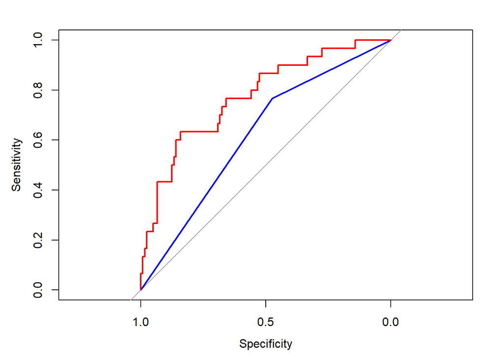

```r
riskscore_ROC_ev <- roc(Guilindata$Metastasis,Guilindata$riskscore,levels=c(control = 0, case = 1),direction="<")
Ngroup_ROC_ev <- roc(Guilindata$Metastasis,Guilindata$Ngroup,levels=c(control = 0, case = 1),direction="<")
#riskscore_ROC_ev$auc; ci(riskscore_ROC_ev)
#Ngroup_ROC_ev$auc
#roc.test(riskscore_ROC_ev,Ngroup_ROC_ev)
plot(Ngroup_ROC_ev,col="blue",lwd=2)
plot(riskscore_ROC_ev,col="red",lwd=2,add=T)
```

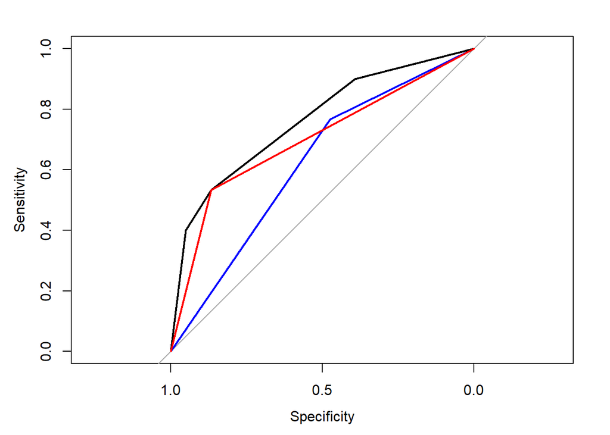

```r
Guilindata$lncRNA_signature <- as.numeric(Guilindata$lncRNA_signature)-1
Guilindata$lnc_N_score <- Guilindata$Ngroup+2*Guilindata$lncRNA_signature
lncsig_ROC_ev <- roc(Guilindata$Metastasis,Guilindata$lncRNA_signature,levels=c(control = 0, case = 1),direction="<")
lnc_N_ROC_ev <- roc(Guilindata$Metastasis,Guilindata$lnc_N_score,levels=c(control = 0, case = 1),direction="<")
#lncsig_ROC_ev$auc
#lnc_N_ROC_ev$auc
#roc.test(Ngroup_ROC_ev,lnc_N_ROC_ev)
#roc.test(lncsig_ROC_ev,lnc_N_ROC_ev)
plot(Ngroup_ROC_ev,col="blue",lwd=2)
plot(lnc_N_ROC_ev,col="black",lwd=2,add=T)
plot(lncsig_ROC_ev,col="red",lwd=2,add=T)
```

forest plot (Fig.3)  
- forestdata is the summary of univariate Cox analyses. Prepare it in a .csv file using excel.

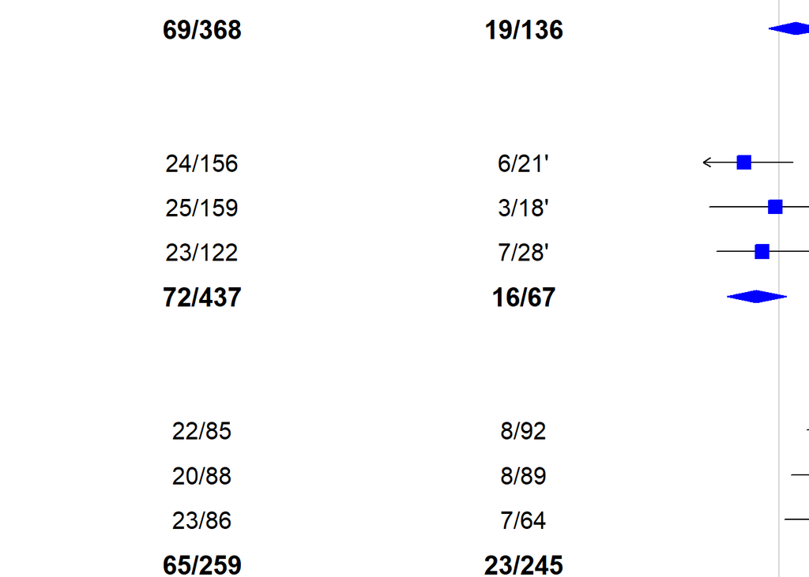

```r
forestdata<-read.csv("forest/forest_uni_DMFSplot.csv")
forestplot(as.matrix(forestdata[,1:5]),
           forestdata$mean,
           forestdata$lower,
           forestdata$upper,
           is.summary=c(T,F,
                        T,F,F,F,T,F,
                        T,F,F,F,T,F,
                        T,F,F,F,T,F,
                        T,F,F,F,T,F,
                        T,F,F,T,F,
                        T,F,F,F,T),
           graph.pos= 4, graphwidth = unit(50,"mm"),
           clip=c(0.25,16),xlog = T, xticks = c(0.25,0.5,1.0,2.0,4.0,8.0,16.0),
           boxsize=0.3,txt_gp = fpTxtGp(cex=1.25),line.margin=unit(5,"mm"), lineheight = unit(10,'mm'),
           hrzl_lines = list("2" = gpar(lty=1)),
           col=fpColors(box="blue",summary="blue",lines = 'black'))
```

## Function implication

Input data  
- Normdata: Normalized data with probename  
- Column 1: probename  
- Column 2 to Column 37 contain data from 18 Healthy controls and 18 matched LA-NPC  
- Column 38 to Column 57 contain data from 10 LA-NPC without metastasis and 10 matched LA-NPC with metastasis

```r
Normdata<-read.csv("Matrix.csv",header=T)
Normdata[1:5,1:5]
```

```
##       ProbeName     HC_01     HC_02     HC_03     HC_04
## 1 ASHGA5P058197  3.956691  4.227693  3.416671  4.148913
## 2 ASHGA5P007773  8.962915  9.273687  9.576827  9.579044
## 3 ASHGA5P031162  2.553897  2.991900  2.716681  3.293391
## 4 ASHGA5P041796 13.671741 13.877446 14.258229 14.259817
## 5 ASHGA5P006930  6.811379  6.858676  7.082864  6.769205
```

- Traits: Information of the 56 samples subjected to microarray profiling,including sample ID, group, batch and risk stratification(only for LA-NPC samples) according to lncRNA signature

```r
Traits <- read.csv("Array_Traits.csv",header = T)
Traits[1:3,]
```

```
##      ID           Group Batch lncRNA_signature
## 1 HC_01 Healthy_control First   Not_applicable
## 2 HC_02 Healthy_control First   Not_applicable
## 3 HC_03 Healthy_control First   Not_applicable
```

- anno: Probe annotation

```r
anno <- read.csv("Probe_anno.csv",header = T)
anno[1:3,]
```

```
##       ProbeName quality_filter        biotype        Trans_ID GeneSymbol
## 1 ASHGA5P058197           fail         lncRNA ENST00000655574  LINC01727
## 2 ASHGA5P007773           pass protein_coding       NM_005065      SEL1L
## 3 ASHGA5P031162           fail         lncRNA ENST00000564510 AC007728.1
```

Data Organization

```r
datamat <- Normdata[,20:57] #Column 20 to Column 57 contain data from LA-NPC
model <- model.matrix(~1,data = data.frame(Traits$Group[19:56]))
combatdata <- ComBat(dat = as.matrix(datamat), batch = Traits$Batch[19:56], mod = model)#remove batch effect
#identical(Normdata$ProbeName,anno$ProbeName)

##mRNA data
rowmRNA <- which(anno$biotype=="protein_coding"&anno$quality_filter=="pass")
mRNA <-combatdata[rowmRNA,]
mRNA <- data.frame(GeneSymbol=anno$GeneSymbol[rowmRNA],mRNA)
mRNA<-mRNA%>%group_by(GeneSymbol)%>%summarise_all(median)%>%as.data.frame()
mRNA <- column_to_rownames(mRNA,"GeneSymbol")

##selected-lncRNA data
rowlnc <- which(anno$Trans_ID %in% selected_lncs) #no duplicates
#anno[rowlnc,"quality_filter"] #all pass quality control
lnc<-combatdata[rowlnc,]
rownames(lnc) <- anno$Trans_ID[rowlnc]
```

lncRNA function implication - hallmarks pathways

```r
dd <- data.frame(msigdbr(species = "Homo sapiens"))
hallmarks <- dd %>% filter(gs_cat == "H") %>% dplyr::select(gs_name,gene_symbol)

hallmark_df<-data.frame()
for (j in selected_lncs){
  y <- as.numeric(lnc[j,])
  rownames <- rownames(mRNA)
  cor_data_df <- data.frame(rownames)
  #correlation analysis
  for (i in 1:length(rownames)){
    test <- cor.test(as.numeric(mRNA[i,]),y,method="spearman")
    cor_data_df[i,2] <- test$estimate
    cor_data_df[i,3] <- test$p.value
  }
  names(cor_data_df) <- c("Genesymbol","correlation","pvalue")

  #prepare data for GSEA
  geneList <- cor_data_df$correlation
  names(geneList) = cor_data_df$Genesymbol
  geneList = sort(geneList, decreasing = TRUE)

  #GSEA
  set.seed(1)
  ResGSEA_hallmark <- GSEA(geneList,TERM2GENE = hallmarks,pvalueCutoff = 1,nPermSimple = 10000)

  tmp<-ResGSEA_hallmark@result
  tmp$lnc<-j
  hallmark_df<-rbind(hallmark_df,tmp)
}
hallmark_sig <- filter(hallmark_df,pvalue < 0.05,qvalues < 0.25)
hallmark_sig <- data.frame(table(hallmark_sig$ID))
```

lncRNA function implication - Immport (Fig.5B)

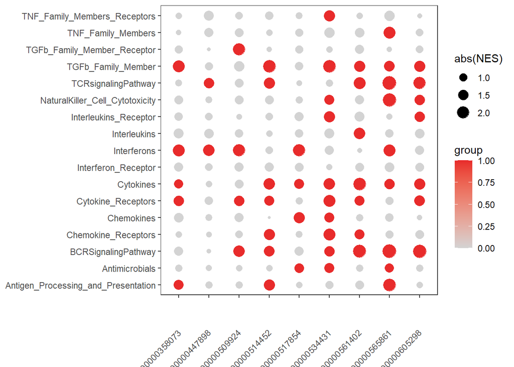

```r
Immport_list <- read.csv("Immport_GeneList.csv",header = T) #Dowloaded from Immport website (https://www.immport.org/home)
Immport_list <- Immport_list[,c(6,1)]

Immport_df<-data.frame()
for (j in selected_lncs){
  y <- as.numeric(lnc[j,])
  rownames <- rownames(mRNA)
  cor_data_df <- data.frame(rownames)
  #correlation analysis
  for (i in 1:length(rownames)){
    test <- cor.test(as.numeric(mRNA[i,]),y,method="spearman")
    cor_data_df[i,2] <- test$estimate
    cor_data_df[i,3] <- test$p.value
  }
  names(cor_data_df) <- c("Genesymbol","correlation","pvalue")

  #prepare data for GSEA
  geneList <- cor_data_df$correlation
  names(geneList) = cor_data_df$Genesymbol
  geneList = sort(geneList, decreasing = TRUE)

  #GSEA
  set.seed(1)
  ResGSEA_Immport <- GSEA(geneList,TERM2GENE = Immport_list,minGSSize = 3,pvalueCutoff = 1,nPermSimple = 10000)

  tmp<-ResGSEA_Immport@result
  tmp$lnc<-j
  Immport_df<-rbind(Immport_df,tmp)
}
# bubble plot
Immport_df<-within (Immport_df, {
  group <- NA
  group [pvalue < 0.05 & qvalues < 0.25]<- 1
  group [pvalue > 0.05 | qvalues > 0.25]<- 0})
ggplot(Immport_df,aes(x=lnc,y=ID))+
  geom_point(aes(size=abs(NES),
                 color=group))+
  theme_bw()+
  theme(panel.grid = element_blank(),
        axis.text.x=element_text(angle=45,hjust = 1,vjust=0.5))+
  scale_color_gradient(low="lightgrey",high="#E82B2B")+
  labs(x=NULL,y=NULL)+
  guides(size=guide_legend(order=3))
```

pathways enriched in high-risk and low-risk group (Fig.5C)

```r
mRNA_dat <- t(mRNA)
#identical(rownames(mRNA_dat),Traits$ID[19:56]) #TRUE
mRNA_dat <- data.frame(cbind(mRNA_dat,lncRNA_signature=Traits$lncRNA_signature[19:56]))

Traits2 <- Traits[19:56,]
#identical(rownames(mRNA_dat),Traits2$ID) #TRUE
Traits2$lncRNA_signature <- as.factor(Traits2$lncRNA_signature)
difmod<-model.matrix(~0+lncRNA_signature, data = Traits2)
colnames(difmod) <- c("highrisk","lowrisk")
conmat<-makeContrasts(contrasts="lowrisk-highrisk",levels=difmod)
fit <- lmFit(mRNA, difmod)
fit1 <- contrasts.fit(fit,conmat)
fit2 <- eBayes(fit1)
Res_limma<-topTable(fit2,coef="lowrisk-highrisk",n=nrow(fit2),adjust="BH")
geneList <- Res_limma$logFC
names(geneList) = rownames(Res_limma)
geneList = sort(geneList, decreasing = TRUE)
set.seed(10)
ResGSEA <- GSEA(geneList,TERM2GENE = hallmarks,pvalueCutoff = 1,nPermSimple = 10000)
tmp1<-ResGSEA@result

##circus plot
dat <- tmp1[which(tmp1$pvalue<0.05),]
dat$ID <- gsub("HALLMARK_", "", dat$ID)
#dat$ID
dat$category <- c('Immune-related','Cancer-related','Immune-related','Other','Cancer-related',
                  'Cancer-related','Immune-related','Cancer-related','Immune-related','Other',
                  "Metabolism-related",'Other','Immune-related','Cancer-related','Cancer-related',
                  'Other','Immune-related',"Metabolism-related",'Cancer-related','Immune-related',
                  'Cancer-related','Other')
dat$gene_num.min <- 0
dat$gene_num.max <- dat$setSize
dat$log10Pvalue <- -log10(dat$pvalue)
dat$rich.factor=abs(dat$NES)
dat$Count <- round(as.numeric(substring(dat$leading_edge, 6, 7))/100*dat$setSize)
dat$up.regulated <- dat$Count
dat<-within (dat, {up.regulated [NES < 0]<- 0})
dat$down.regulated <- dat$Count
dat<-within (dat, {down.regulated [NES > 0]<- 0})
rownames(dat) <- dat$ID
dat <- dat[order(dat$category),]
dat[1:3,]
```

```
##                                                                  ID
## EPITHELIAL_MESENCHYMAL_TRANSITION EPITHELIAL_MESENCHYMAL_TRANSITION
## ANGIOGENESIS                                           ANGIOGENESIS
## P53_PATHWAY                                             P53_PATHWAY
##                                                                  Description
## EPITHELIAL_MESENCHYMAL_TRANSITION HALLMARK_EPITHELIAL_MESENCHYMAL_TRANSITION
## ANGIOGENESIS                                           HALLMARK_ANGIOGENESIS
## P53_PATHWAY                                             HALLMARK_P53_PATHWAY
##                                   setSize enrichmentScore       NES
## EPITHELIAL_MESENCHYMAL_TRANSITION     194      -0.7012107 -3.076259
## ANGIOGENESIS                           36      -0.7308751 -2.385584
## P53_PATHWAY                           190      -0.4596198 -2.011862
##                                         pvalue     p.adjust      qvalues rank
## EPITHELIAL_MESENCHYMAL_TRANSITION 1.000000e-10 1.250000e-09 7.368421e-10 1654
## ANGIOGENESIS                      1.389729e-08 1.389729e-07 8.192087e-08 1461
## P53_PATHWAY                       2.544291e-08 2.120243e-07 1.249827e-07 3068
##                                                     leading_edge
## EPITHELIAL_MESENCHYMAL_TRANSITION  tags=45%, list=9%, signal=42%
## ANGIOGENESIS                       tags=53%, list=8%, signal=49%
## P53_PATHWAY                       tags=32%, list=17%, signal=27%
##                                                                                                                                                                                                                                                                                                          …
## EPITHELIAL_MESENCHYMAL_TRANSITION PDLIM4/NID2/ITGB3/NNMT/GADD45B/LAMA1/THBS1/GREM1/SERPINE1/CD…
## ANGIOGENESIS                                                                                                                                                                                                                                                                                             …
## P53_PATHWAY                                                                                                                                                                                        EI24/PPM1D/SEC61A1/SLC3A2/EPHX1/TNFSF9/PLK2/RGS16/ZNF365/RAP…
##                                         category gene_num.min gene_num.max
## EPITHELIAL_MESENCHYMAL_TRANSITION Cancer-related            0          194
## ANGIOGENESIS                      Cancer-related            0           36
## P53_PATHWAY                       Cancer-related            0          190
##                                   log10Pvalue rich.factor Count up.regulated
## EPITHELIAL_MESENCHYMAL_TRANSITION   10.000000    3.076259    87            0
## ANGIOGENESIS                         7.857070    2.385584    19            0
## P53_PATHWAY                          7.594433    2.011862    61            0
##                                   down.regulated
## EPITHELIAL_MESENCHYMAL_TRANSITION             87
## ANGIOGENESIS                                  19
## P53_PATHWAY                                   61
```

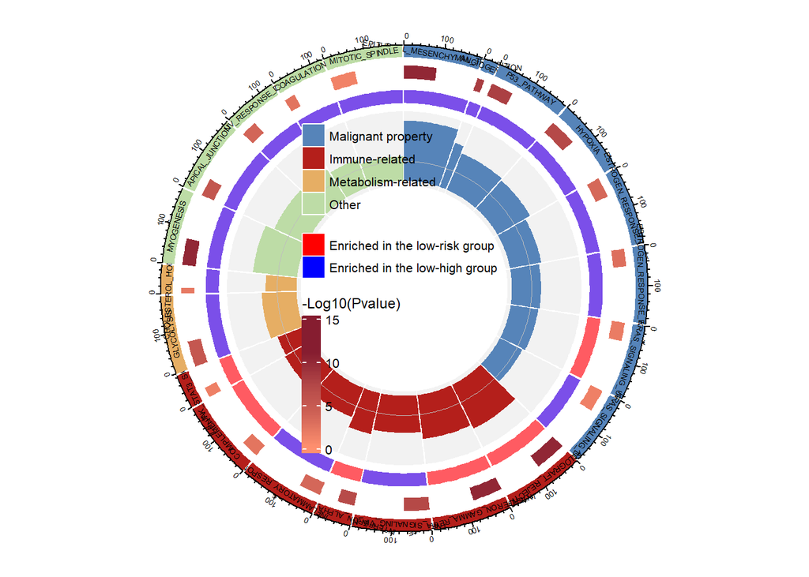

```r
#outmost circle (Track1)
circos.par(gap.degree = 0.5, start.degree = 90)
plot_data <- dat[c('ID', 'gene_num.min', 'gene_num.max')]
color_assign <- c('Cancer-related' = "#5684B9", 'Immune-related' = "#B41F1B",
                  'Metabolism-related' = "#E6AE64",'Other'="#BDDCA6")
ko_color <- color_assign[dat$category]

circos.genomicInitialize(plot_data, plotType = NULL, major.by = 1)
circos.track(
  ylim = c(0, 1), track.height = 0.05, bg.border = NA, bg.col = ko_color,
  panel.fun = function(x, y) {
    ylim = get.cell.meta.data('ycenter')#ylim、xlim
    xlim = get.cell.meta.data('xcenter')
    sector.name = get.cell.meta.data('sector.index')#sector.name
    circos.axis(h = 'top', labels.cex = 0.4, labels.niceFacing = FALSE)
    circos.text(xlim, ylim, sector.name, cex = 0.4, niceFacing = FALSE)
  } )

#Track2
plot_data <- dat[c('ID', 'gene_num.min', 'Count', 'log10Pvalue')]
label_data <- dat['Count']
p_max <- round(max(dat$'log10Pvalue')) + 1
colorsChoice <- colorRampPalette(c('#FF906F', '#861D30'))
color_assign <- colorRamp2(breaks = 0:p_max, col = colorsChoice(p_max + 1))

circos.genomicTrackPlotRegion(
  plot_data, track.height = 0.08, bg.border = NA, stack = TRUE,
  panel.fun = function(region, value,...) {
    circos.genomicRect(region, value, col = color_assign(value[[1]]), border = NA,...)
    ylim = get.cell.meta.data('ycenter')
    xlim = label_data[get.cell.meta.data('sector.index'),1] / 2
    sector.name = label_data[get.cell.meta.data('sector.index'),1]
    #circos.text(xlim, ylim, sector.name, cex = 0.4, niceFacing = FALSE)
  } )

#Track3
dat$all.regulated <- dat$up.regulated + dat$down.regulated
dat$up.proportion <- dat$up.regulated / dat$all.regulated
dat$down.proportion <- dat$down.regulated / dat$all.regulated

dat$up <- dat$up.proportion * dat$gene_num.max
plot_data_up <- dat[c('ID', 'gene_num.min', 'up')]
names(plot_data_up) <- c('ID', 'start', 'end')
plot_data_up$type <- 1

dat$down <- dat$down.proportion * dat$gene_num.max + dat$up
plot_data_down <- dat[c('ID', 'up', 'down')]
names(plot_data_down) <- c('ID', 'start', 'end')
plot_data_down$type <- 2

plot_data <- rbind(plot_data_up, plot_data_down)
label_data <- dat[c('up', 'down', 'up.regulated', 'down.regulated')]
color_assign <- colorRamp2(breaks = c(1, 2), col = c("#FF5B62", "#7B4FE9"))

circos.genomicTrackPlotRegion(
  plot_data, track.height = 0.08, bg.border = NA, stack = TRUE,
  panel.fun = function(region, value, ...) {
    circos.genomicRect(region, value, col = color_assign(value[[1]]), border = NA, ...)
    ylim = get.cell.meta.data('cell.bottom.radius') - 0.5
    xlim = label_data[get.cell.meta.data('sector.index'),1] / 2
    sector.name = label_data[get.cell.meta.data('sector.index'),3]
    xlim = (label_data[get.cell.meta.data('sector.index'),2]+label_data[get.cell.meta.data('sector.index'),1]) / 2
    sector.name = label_data[get.cell.meta.data('sector.index'),4]
  } )

#Track4
plot_data <- dat[c('ID', 'gene_num.min', 'gene_num.max', 'rich.factor')]
label_data <- dat['category']
color_assign <- c('Cancer-related' = "#5684B9", 'Immune-related' = "#B41F1B",
                  'Metabolism-related' = "#E6AE64",'Other'="#BDDCA6")
circos.genomicTrack(
  plot_data, ylim = c(0, 1), track.height = 0.3, bg.col = 'gray95', bg.border = NA,
  panel.fun = function(region, value, ...) {
    sector.name = get.cell.meta.data('sector.index')  #sector.name
    circos.genomicRect(region, value*0.3, col = color_assign[label_data[sector.name,1]], border = NA, ytop.column = 1, ybottom = 0, ...)
    circos.lines(c(0, max(region)), c(0.3,0.3), col = 'gray', lwd = 0.3)
  } )

category_legend <- Legend(
  labels = c('Malignant property','Immune-related', 'Metabolism-related', 'Other'),
  type = 'points', pch = NA,
  background = c("#5684B9","#B41F1B","#E6AE64","#BDDCA6"),
  labels_gp = gpar(fontsize = 8), grid_height = unit(0.5, 'cm'), grid_width = unit(0.5, 'cm'))

updown_legend <- Legend(
  labels = c('Enriched in the low-risk group', 'Enriched in the low-high group'),
  type = 'points', pch = NA, background = c('red', 'blue'),
  labels_gp = gpar(fontsize = 8), grid_height = unit(0.5, 'cm'), grid_width = unit(0.5, 'cm'))

pvalue_legend <- Legend(
  col_fun = colorRamp2(round(seq(0, p_max, length.out = 6), 0),
                       colorRampPalette(c('#FF906F', '#861D30'))(6)),
  legend_height = unit(3, 'cm'), labels_gp = gpar(fontsize = 8),
  title_gp = gpar(fontsize = 9), title_position = 'topleft', title = '-Log10(Pvalue)')

lgd_list_vertical <- packLegend(category_legend, updown_legend, pvalue_legend)
grid.draw(lgd_list_vertical)
```

```r
circos.clear()
```

heatmap of immune-related genes (Fig.5D)

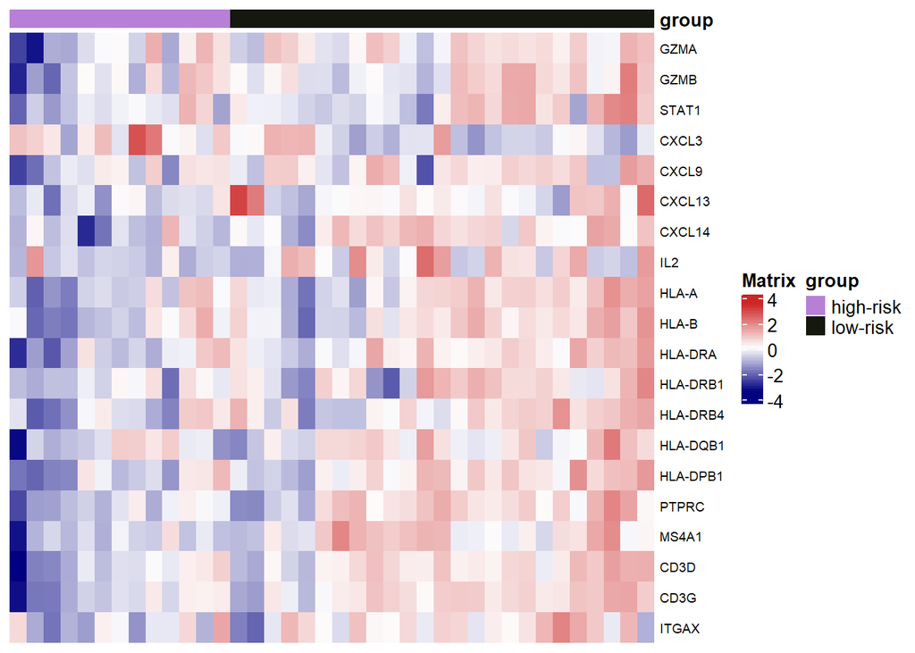

```r
heatdat <- mRNA[c("GZMA","GZMB","STAT1","CXCL3","CXCL9","CXCL13","CXCL14","IL2","HLA-A", "HLA-B", "HLA-DRA","HLA-DRB1","HLA-DRB4","HLA-DQB1","HLA-DPB1","PTPRC","MS4A1","CD3D","CD3G","ITGAX"),]
heatdat <- heatdat[,c("NPC_08","NPC_22","NPC_31","NPC_29","NPC_07","NPC_21",
                      "NPC_32","NPC_36","NPC_12","NPC_09","NPC_14","NPC_38",
                      "NPC_35","NPC_11","NPC_17","NPC_18","NPC_19","NPC_20",
                      "NPC_16","NPC_30","NPC_10","NPC_03","NPC_04","NPC_33",
                      "NPC_05","NPC_02","NPC_24","NPC_25","NPC_23","NPC_13",
                      "NPC_15","NPC_26","NPC_01","NPC_34","NPC_27","NPC_28",
                      "NPC_06","NPC_37")]
annotation_col1 <- data.frame(group=factor(Traits$lncRNA_signature[19:56]))
rownames(annotation_col1) = Traits$ID[19:56]
ann_colors1 = list(Type = c("0" = "#33A02CFF", "1" = "#FF7F00FF"))
pheatmap(as.matrix(heatdat), scale = "row", cluster_row = FALSE,cluster_col = FALSE,
         treeheight_row=0,treeheight_col=25,
         color = colorRampPalette(c("navy", "white", "firebrick3"))(50),
         border_color=FALSE,fontsize=7,show_rownames = T,show_colnames = F,
         annotation_col = annotation_col1,annotation_colors = ann_colors1)
```

## Immune infiltration

MCPcounter (Fig.6A)

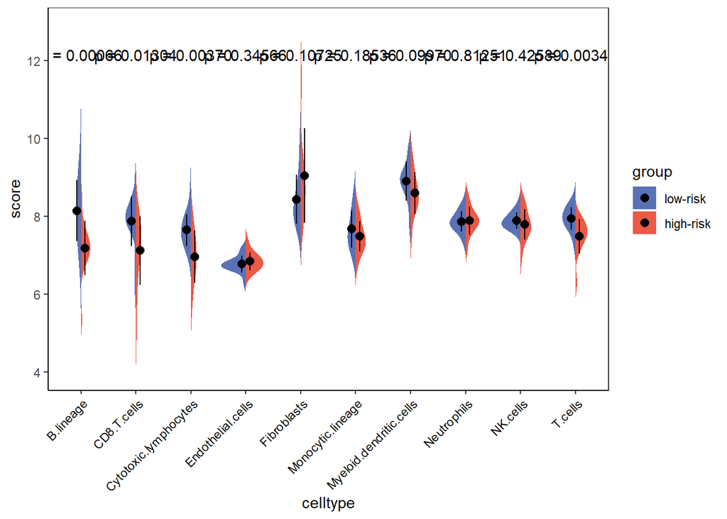

```r
genes <- data.table::fread("Signatures/genes.txt",data.table = F)
probesets <- data.table::fread("Signatures/probesets.txt",data.table = F,header = F)
lncArray_MCPcounter_results<- MCPcounter.estimate(mRNA,
                                                  featuresType= "HUGO_symbols",
                                                  probesets=probesets,
                                                  genes=genes)
dd1 <- data.frame(t(lncArray_MCPcounter_results)) %>% rownames_to_column()
#identical(dd1$rowname,Traits$ID[19:56]) #TRUE
dd1$Group2 <- Traits$lncRNA_signature[19:56]
dd2 <- dd1 %>% pivot_longer(cols = 2:11,names_to = "celltype",values_to = "score")
dd2$Group2 <- factor(dd2$Group2,levels = c("low-risk","high-risk"))

colors = c("#5a72b5","#ea5a49")
su2 = group_by(dd2,Group2,celltype) %>%
  summarise(s = sd(score),score = mean(score))
p = ggplot(dd2, aes(x = celltype, y = score,fill= Group2))+
  geom_split_violin(trim = FALSE,color = NA,adjust = 1.5)+
  guides(fill=guide_legend(title="group"))+
  scale_fill_manual(values = colors)+
  theme_bw()
p + geom_point(data = su2,aes(x = celltype, y = score),
               pch=19,position=position_dodge(0.3),size=2.5)+
  geom_errorbar(data = su2,
                mapping = aes(ymin = score-s, ymax = score+s),
                width=0,
                position=position_dodge(0.3),
                color="black",
                size=0.5)+
  theme(axis.text.x = element_text(angle = 45, hjust = 1,vjust = 1, colour = "black"))+
  theme(panel.grid.major =element_blank(), panel.grid.minor = element_blank(),panel.background = element_blank(),axis.line = element_line(colour = "black"))+
  theme(strip.background = element_blank(),strip.text = element_text(size = 10))+
  stat_compare_means(aes(group = Group2), label = "p.format",label.y = 12, method="t.test")
```

Immune infiltration by IHC image analysis (Fig.6D)  
- IHCdata: Results of IHC image analysis

```r
IHCdata <- read.csv("SYSUdata_IHC.csv",header = T,row.names = 1)
head(IHCdata)
```

```
##      Intratumor_CD8 Stromal_CD8 Intratumor_CD20 Stromal_CD20
## T001             NA          NA              NA           NA
## T003             NA          NA              NA           NA
## T006             NA          NA              NA           NA
## T009           1263        2098            4930         8006
## T012           2706        2707            1582         2118
## T020           5351        6441            6684         7601
```

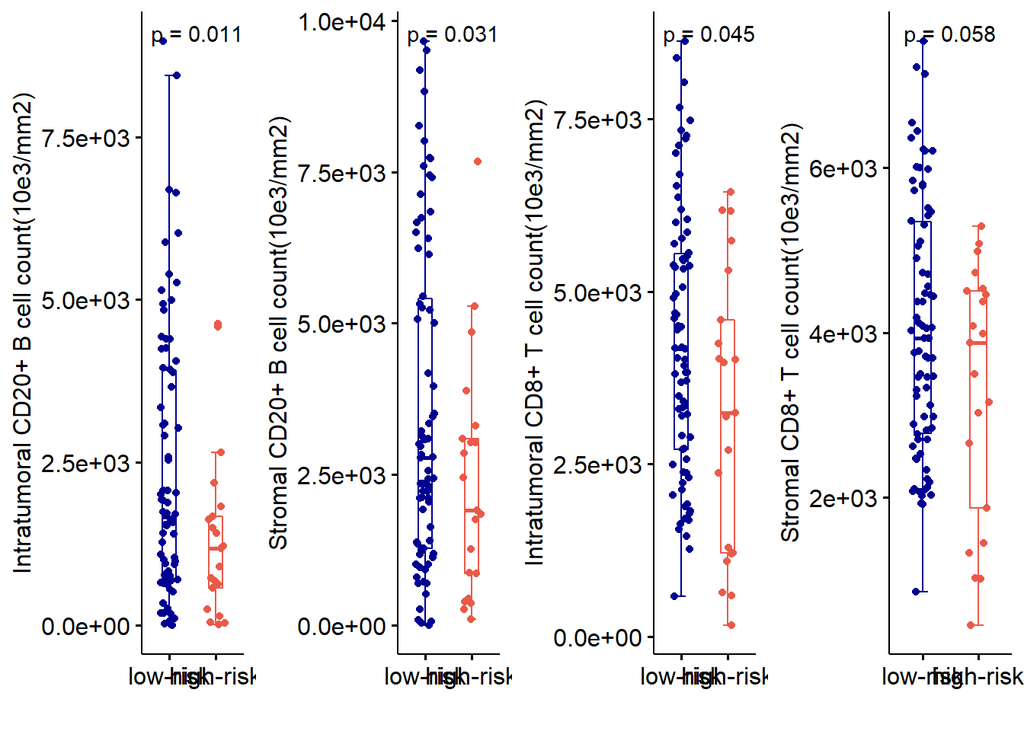

```r
common_col <- intersect(colnames(data_train),colnames(data_invd))
data_train2 <- data_train[,common_col]
data_invd2 <- data_invd[,common_col]
SYSUdata <- rbind(data_train2,data_invd2)

loc <- match(rownames(IHCdata),rownames(SYSUdata))
SYSU_IHCdata <- cbind(IHCdata,SYSUdata[loc,])
SYSU_IHCdata<-within (SYSU_IHCdata, {
  riskgroup <-NA
  riskgroup [lncRNA_signature == 0]<-"low-risk"
  riskgroup [lncRNA_signature == 1]<-"high-risk"})

##boxplot
p1 <- ggboxplot(SYSU_IHCdata, x = "riskgroup", y = "Intratumor_CD20",
          color = "riskgroup",palette = c("#000091","#ea5a49"),
          add = c("jitter"),width = 0.3,
          bxp.errorbar=T,bxp.errorbar.width = 0.2)+
  theme(legend.position = "none")+
  scale_y_continuous(labels = scientific)+
  labs(x="",y="Intratumoral CD20+ B cell count(10e3/mm2)")+
  stat_compare_means(aes(group = riskgroup), label = "p.format", method="t.test")

p2 <- ggboxplot(SYSU_IHCdata, x = "riskgroup", y = "Stromal_CD20",
          color = "riskgroup",palette = c("#000091","#ea5a49"),
          add = c("jitter"),width = 0.3,
          bxp.errorbar=T,bxp.errorbar.width = 0.2)+
  theme(legend.position = "none")+
  scale_y_continuous(labels = scientific)+
  labs(x="",y="Stromal CD20+ B cell count(10e3/mm2)")+
  stat_compare_means(aes(group = riskgroup), label = "p.format", method="t.test")

p3 <- ggboxplot(SYSU_IHCdata, x = "riskgroup", y = "Intratumor_CD8",
          color = "riskgroup",palette = c("#000091","#ea5a49"),
          add = c("jitter"),width = 0.3,
          bxp.errorbar=T,bxp.errorbar.width = 0.2)+
  theme(legend.position = "none")+
  scale_y_continuous(labels = scientific)+
  labs(x="",y="Intratumoral CD8+ T cell count(10e3/mm2)")+
  stat_compare_means(aes(group = riskgroup), label = "p.format", method="t.test")

p4 <- ggboxplot(SYSU_IHCdata, x = "riskgroup", y = "Stromal_CD8",
          color = "riskgroup",palette = c("#000091","#ea5a49"),
          add = c("jitter"),width = 0.3,
          bxp.errorbar=T,bxp.errorbar.width = 0.2)+
  theme(legend.position = "none")+
  scale_y_continuous(labels = scientific)+
  labs(x="",y="Stromal CD8+ T cell count(10e3/mm2)")+
  stat_compare_means(aes(group = riskgroup), label = "p.format", method="t.test")

plot_grid(p1, p2, p3, p4, ncol = 4)
```